# BASIL Reference Standard (Clinical Assessor)

Author

Affiliation

Doug Tommet and Rich Jones for Anna MacKay-Brandt, Tamara G Fong, and the BASIL-II team

Presented on June 27, 2025

Published

October 8, 2026

```
=== Project environment ready ===
Project root: /Users/rnj/DWork/GitHub/BASIL-II-RS
```

## Aims of manuscript:

1. Describe clinical assessor inter-rater reliability for *delirium severity* ratings:
   1. Overall agreement among clinical assessors
      1. Before consensus meeting *(for generalizability - this is the result that is [more or less] generalizable to other research studies using a single clinical rater for delirium)*
      2. After consensus meeting *(this is the result that describes the reliability of the clinical assessor rating of delirium in the BASIL-II study)*.
   2. Variability in agreement as a function delirium severity (Bland-Altman plots)
2. Explore if there are *delirium features* that are associated with delirium severity inter-rater agreement (e.g., features present include Inattention, Disorganized Thinking, Altered Level of Consciousness, Disorientation, Memory Impairment, Perceptual Disturbances, Psychomotor Agitation, Psychomotor Retardation, Altered Sleep-Wake, Inappropriate Behavior, Delusions).
3. Explore if there are *patient characteristics* that may influence delirium severity inter-rater agreement (e.g., pre-acute cognitive status (NC, MCI, Dementia), three distinct study sites: (1) acute medical inpatients; (2) scheduled surgical inpatients, and (3) long-term and post-acute care residents; informant (family member/friend, nurse, CNA), pre-acute depression)

Note: Aims of manuscript copied from Statistical Analysis Plan ([GDoc](https://docs.google.com/document/d/1GPIzetmxAJxbsQnpXG5_sj9buN0inlTDNljtyg4V1vE/edit?usp=sharing))

## This analysis report (27 June 2025)

- The IPTW weights were calculated and incorporated into the results.
- The scatter plot figures were updated, with circle size representing n and marginal sample sizes in the margins.
- To Do: Update the Bland-Altman figures.
- **ACTION**: Need to generate VDSs for ADL and IADL characteristics
- **ACTION**: Replace REDCap PHQ, MoCA, and AD-8 summary measures with VDS versions
- **ACTION** Aim 2 additionally requires individual CAM-S delirium features (inattention, disorganized thinking, altered level of consciousness, disorientation, memory impairment, perceptual disturbances, psychomotor agitation, psychomotor retardation, altered sleep-wake, inappropriate behavior, delusions), need to modify vds for CAM-S to generate and save individual indicators for the CAM features (0/1)

# IPTW

## Comparison of clinical assessor sample

|  | In the clinical adjudication sample FALSE | In the clinical adjudication sample TRUE | Total |  |
| --- | --- | --- | --- | --- |
| Delirium severity (GS) |  |  |  |  |
| 0 | 217 (49%) | 21 (46%) | 238 (49%) |  |
| 1 | 66 (15%) | 4 (8.7%) | 70 (14%) |  |
| 2 | 22 (5.0%) | 0 (0%) | 22 (4.5%) |  |
| 3 | 28 (6.3%) | 2 (4.3%) | 30 (6.1%) |  |
| 4 | 47 (11%) | 7 (15%) | 54 (11%) |  |
| 5 | 37 (8.4%) | 4 (8.7%) | 41 (8.4%) |  |
| 6 | 17 (3.8%) | 5 (11%) | 22 (4.5%) |  |
| 7 | 4 (0.9%) | 2 (4.3%) | 6 (1.2%) |  |
| 8 | 4 (0.9%) | 1 (2.2%) | 5 (1.0%) |  |
| 9 | 0 (0%) | 0 (0%) | 0 (0%) |  |
| 10 | 0 (0%) | 0 (0%) | 0 (0%) |  |
| Total | 442 (100%) | 46 (100%) | 488 (100%) |  |

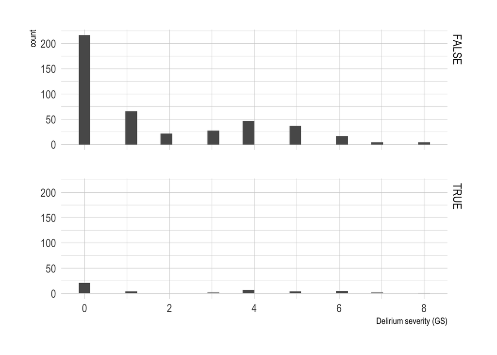

## Calculating the weights

We considered two methods to calculate the weights. The first was using logistic regression. The second was called entropy balancing. Both models controlled for delirium severity (GS) and site. We are going with the entropy balancing weights.

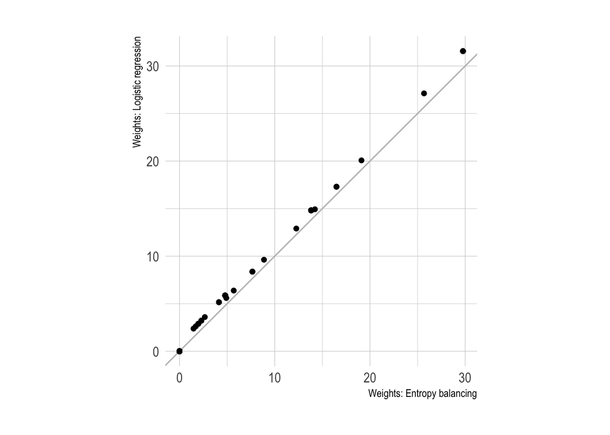

## Comparison of weighted and unweighted sample

Mean of delirium severity, stratified by clinical assessor sample.

| **Characteristic** | **Overall** N = 488<sup>1</sup> | **TRUE** N = 46<sup>1</sup> | **FALSE** N = 442<sup>1</sup> |
| --- | --- | --- | --- |
| Delirium severity (GS) | 1.72 (2.16) | 2.39 (2.64) | 1.65 (2.10) |

<sup>1</sup> Mean (SD)

Weighted mean of delirium severity in the clinical assessor sample.

| **Characteristic** | **N = 442**<sup>1</sup> |
| --- | --- |
| Delirium severity (GS) | 1.65 (2.20) |

<sup>1</sup> Mean (SD)

# Table 1

Table 1: Descriptive statistics of the RS sample

| **Characteristic** | **Overall** N = 46<sup>1</sup> | **BIDMC** N = 10<sup>1</sup> | **UF** N = 14<sup>1</sup> | **TNJH** N = 22<sup>1</sup> |
| --- | --- | --- | --- | --- |
| Age | 80.0 (6.2) | 80.1 (7.2) | 77.4 (3.9) | 81.5 (6.7) |
| Female |  |  |  |  |
| 0 | 19 (41%) | 4 (40%) | 7 (50%) | 8 (36%) |
| 1 | 27 (59%) | 6 (60%) | 7 (50%) | 14 (64%) |
| Non-white |  |  |  |  |
| 0 | 31 (67%) | 8 (80%) | 13 (93%) | 10 (45%) |
| 1 | 15 (33%) | 2 (20%) | 1 (7.1%) | 12 (55%) |
| Racial Group |  |  |  |  |
| 1 | 31 (67%) | 8 (80%) | 13 (93%) | 10 (45%) |
| 2 | 13 (28%) | 2 (20%) | 1 (7.1%) | 10 (45%) |
| 5 | 2 (4.3%) | 0 (0%) | 0 (0%) | 2 (9.1%) |
| Hispanic ethnicity |  |  |  |  |
| 0 | 46 (100%) | 10 (100%) | 14 (100%) | 22 (100%) |
| English is second language |  |  |  |  |
| 0 | 45 (98%) | 10 (100%) | 14 (100%) | 21 (95%) |
| 1 | 1 (2.2%) | 0 (0%) | 0 (0%) | 1 (4.5%) |
| Education | 14.3 (3.2) | 14.5 (2.7) | 14.7 (2.6) | 14.0 (3.7) |
| Unknown | 1 | 0 | 0 | 1 |
| Lives alone |  |  |  |  |
| 0 | 37 (80%) | 5 (50%) | 10 (71%) | 22 (100%) |
| 1 | 9 (20%) | 5 (50%) | 4 (29%) | 0 (0%) |
| Married |  |  |  |  |
| 0 | 31 (67%) | 8 (80%) | 4 (29%) | 19 (86%) |
| 1 | 15 (33%) | 2 (20%) | 10 (71%) | 3 (14%) |
| Lives in NH |  |  |  |  |
| 0 | 24 (52%) | 10 (100%) | 14 (100%) | 0 (0%) |
| 1 | 22 (48%) | 0 (0%) | 0 (0%) | 22 (100%) |
| Vision impairment |  |  |  |  |
| 0 | 25 (61%) | 8 (80%) | 11 (79%) | 6 (35%) |
| 1 | 16 (39%) | 2 (20%) | 3 (21%) | 11 (65%) |

[output cut: 54 more lines]

<sup>1</sup> Mean (SD); n (%)

Table 2: Descriptive statistics of the RS sample (weighted)

| **Characteristic** | **Overall** N = 442<sup>1</sup> | **BIDMC** N = 210<sup>1</sup> | **UF** N = 153<sup>1</sup> | **TNJH** N = 79<sup>1</sup> |
| --- | --- | --- | --- | --- |
| Age | 79 (6) | 80 (7) | 77 (3) | 81 (7) |
| Female |  |  |  |  |
| 0 | 188 (42%) | 75 (36%) | 82 (54%) | 30 (38%) |
| 1 | 254 (58%) | 135 (64%) | 71 (46%) | 49 (62%) |
| Non-white |  |  |  |  |
| 0 | 349 (79%) | 164 (78%) | 147 (96%) | 38 (48%) |
| 1 | 93 (21%) | 46 (22%) | 6 (3.7%) | 41 (52%) |
| Racial Group |  |  |  |  |
| 1 | 349 (79%) | 164 (78%) | 147 (96%) | 38 (48%) |
| 2 | 86 (20%) | 46 (22%) | 6 (3.7%) | 35 (44%) |
| 5 | 7 (1.5%) | 0 (0%) | 0 (0%) | 7 (8.2%) |
| Hispanic ethnicity |  |  |  |  |
| 0 | 442 (100%) | 210 (100%) | 153 (100%) | 79 (100%) |
| English is second language |  |  |  |  |
| 0 | 437 (99%) | 210 (100%) | 153 (100%) | 74 (94%) |
| 1 | 5 (1.1%) | 0 (0%) | 0 (0%) | 5 (6.1%) |
| Education | 14.61 (2.92) | 14.70 (2.84) | 15.04 (2.75) | 13.48 (3.63) |
| Unknown | 5 | 0 | 0 | 5 |
| Lives alone |  |  |  |  |
| 0 | 286 (65%) | 92 (44%) | 115 (75%) | 79 (100%) |
| 1 | 156 (35%) | 118 (56%) | 38 (25%) | 0 (0%) |
| Married |  |  |  |  |
| 0 | 270 (61%) | 161 (77%) | 38 (25%) | 71 (90%) |
| 1 | 172 (39%) | 49 (23%) | 115 (75%) | 8 (10%) |
| Lives in NH |  |  |  |  |
| 0 | 363 (82%) | 210 (100%) | 153 (100%) | 0 (0%) |
| 1 | 79 (18%) | 0 (0%) | 0 (0%) | 79 (100%) |
| Vision impairment |  |  |  |  |
| 0 | 336 (79%) | 181 (86%) | 126 (82%) | 29 (46%) |
| 1 | 89 (21%) | 29 (14%) | 27 (18%) | 33 (54%) |

[output cut: 54 more lines]

<sup>1</sup> Mean (SD); n (%)

# Rater agreement

## Delirium severity

Crosstab of paired initial ratings of delirium severity

|  | Delirium Severity (Rater A) 0 | Delirium Severity (Rater A) 1 | Delirium Severity (Rater A) 2 | Delirium Severity (Rater A) 3 | Delirium Severity (Rater A) 4 | Delirium Severity (Rater A) 5 | Delirium Severity (Rater A) 6 | Delirium Severity (Rater A) 7 | Delirium Severity (Rater A) 8 | Delirium Severity (Rater A) 9 | Total |  |
| --- | --- | --- | --- | --- | --- | --- | --- | --- | --- | --- | --- | --- |
| Delirium Severity (Rater B) |  |  |  |  |  |  |  |  |  |  |  |  |
| 0 | 218 | 57 | 40 | 18 | 2 | 3 | 0 | 0 | 0 | 0 | 338 |  |
| 1 | 60 | 31 | 19 | 17 | 7 | 7 | 0 | 0 | 0 | 0 | 141 |  |
| 2 | 7 | 7 | 5 | 5 | 1 | 0 | 0 | 0 | 0 | 0 | 25 |  |
| 3 | 14 | 6 | 7 | 2 | 7 | 8 | 3 | 1 | 0 | 0 | 48 |  |
| 4 | 14 | 12 | 5 | 12 | 24 | 18 | 4 | 7 | 0 | 0 | 96 |  |
| 5 | 0 | 1 | 0 | 4 | 22 | 36 | 30 | 17 | 3 | 5 | 118 |  |
| 6 | 0 | 1 | 0 | 1 | 14 | 27 | 21 | 22 | 6 | 6 | 98 |  |
| 7 | 0 | 0 | 0 | 0 | 3 | 16 | 19 | 13 | 2 | 5 | 58 |  |
| 8 | 0 | 0 | 0 | 0 | 0 | 0 | 1 | 2 | 7 | 9 | 19 |  |
| 9 | 0 | 0 | 0 | 0 | 0 | 0 | 4 | 0 | 5 | 4 | 13 |  |
| Total | 313 | 115 | 76 | 59 | 80 | 115 | 82 | 62 | 23 | 29 | 954 |  |

Crosstab of paired initial ratings of delirium severity (weighted)

| Delirium Severity B | Delirium Severity A 0 | Delirium Severity A 1 | Delirium Severity A 2 | Delirium Severity A 3 | Delirium Severity A 4 | Delirium Severity A 5 | Delirium Severity A 6 | Delirium Severity A 7 | Delirium Severity A 8 | Delirium Severity A 9 |
| --- | --- | --- | --- | --- | --- | --- | --- | --- | --- | --- |
| 0 | 301.1 | 58.3 | 22.6 | 16.4 | 1.3 | 1.3 | 0.0 | 0.0 | 0.0 | 0.0 |
| 1 | 80.4 | 43.2 | 15.8 | 21.9 | 13.1 | 4.3 | 0.0 | 0.0 | 0.0 | 0.0 |
| 2 | 4.4 | 5.4 | 3.4 | 3.4 | 0.5 | 0.0 | 0.0 | 0.0 | 0.0 | 0.0 |
| 3 | 20.2 | 7.5 | 4.7 | 1.3 | 10.2 | 8.4 | 2.2 | 1.7 | 0.0 | 0.0 |
| 4 | 15.0 | 13.4 | 3.7 | 13.9 | 31.9 | 21.9 | 3.6 | 7.5 | 0.0 | 0.0 |
| 5 | 0.0 | 1.7 | 0.0 | 4.2 | 22.6 | 23.6 | 18.2 | 9.9 | 0.7 | 2.2 |
| 6 | 0.0 | 1.7 | 0.0 | 1.7 | 16.1 | 17.0 | 13.8 | 15.4 | 1.2 | 1.9 |
| 7 | 0.0 | 0.0 | 0.0 | 0.0 | 0.9 | 8.8 | 10.6 | 9.6 | 0.5 | 1.5 |
| 8 | 0.0 | 0.0 | 0.0 | 0.0 | 0.0 | 0.0 | 0.2 | 0.5 | 1.6 | 2.0 |
| 9 | 0.0 | 0.0 | 0.0 | 0.0 | 0.0 | 0.0 | 0.6 | 0.0 | 0.9 | 0.7 |

Crosstab of paired consensus ratings of delirium severity

|  | Delirium Severity (Rater A) 0 | Delirium Severity (Rater A) 1 | Delirium Severity (Rater A) 2 | Delirium Severity (Rater A) 3 | Delirium Severity (Rater A) 4 | Delirium Severity (Rater A) 5 | Delirium Severity (Rater A) 6 | Delirium Severity (Rater A) 7 | Delirium Severity (Rater A) 8 | Delirium Severity (Rater A) 9 | Total |  |
| --- | --- | --- | --- | --- | --- | --- | --- | --- | --- | --- | --- | --- |
| Delirium Severity (Rater B) |  |  |  |  |  |  |  |  |  |  |  |  |
| 0 | 212 | 54 | 42 | 0 | 0 | 0 | 0 | 0 | 0 | 0 | 308 |  |
| 1 | 51 | 55 | 28 | 16 | 0 | 0 | 0 | 0 | 0 | 0 | 150 |  |
| 2 | 14 | 17 | 26 | 6 | 9 | 0 | 0 | 0 | 0 | 0 | 72 |  |
| 3 | 0 | 10 | 4 | 11 | 7 | 0 | 0 | 0 | 0 | 0 | 32 |  |
| 4 | 0 | 0 | 7 | 5 | 31 | 16 | 5 | 0 | 0 | 0 | 64 |  |
| 5 | 0 | 0 | 0 | 1 | 18 | 45 | 54 | 8 | 0 | 0 | 126 |  |
| 6 | 0 | 0 | 0 | 0 | 5 | 34 | 51 | 16 | 0 | 0 | 106 |  |
| 7 | 0 | 0 | 0 | 0 | 0 | 18 | 24 | 12 | 5 | 3 | 62 |  |
| 8 | 0 | 0 | 0 | 0 | 0 | 0 | 0 | 2 | 9 | 10 | 21 |  |
| 9 | 0 | 0 | 0 | 0 | 0 | 0 | 0 | 2 | 7 | 4 | 13 |  |
| Total | 277 | 136 | 107 | 39 | 70 | 113 | 134 | 40 | 21 | 17 | 954 |  |

| Delirium Severity B | Delirium Severity A 0 | Delirium Severity A 1 | Delirium Severity A 2 | Delirium Severity A 3 | Delirium Severity A 4 | Delirium Severity A 5 | Delirium Severity A 6 | Delirium Severity A 7 | Delirium Severity A 8 | Delirium Severity A 9 |
| --- | --- | --- | --- | --- | --- | --- | --- | --- | --- | --- |
| 0 | 296.8 | 56.1 | 29.5 | 0.0 | 0.0 | 0.0 | 0.0 | 0.0 | 0.0 | 0.0 |
| 1 | 82.1 | 79.3 | 23.9 | 14.1 | 0.0 | 0.0 | 0.0 | 0.0 | 0.0 | 0.0 |
| 2 | 16.0 | 13.9 | 14.2 | 4.1 | 4.3 | 0.0 | 0.0 | 0.0 | 0.0 | 0.0 |
| 3 | 0.0 | 8.2 | 3.2 | 8.5 | 6.5 | 0.0 | 0.0 | 0.0 | 0.0 | 0.0 |
| 4 | 0.0 | 0.0 | 5.6 | 6.4 | 36.2 | 23.8 | 8.6 | 0.0 | 0.0 | 0.0 |
| 5 | 0.0 | 0.0 | 0.0 | 2.0 | 24.7 | 28.4 | 31.9 | 4.3 | 0.0 | 0.0 |
| 6 | 0.0 | 0.0 | 0.0 | 0.0 | 8.6 | 24.9 | 41.5 | 7.3 | 0.0 | 0.0 |
| 7 | 0.0 | 0.0 | 0.0 | 0.0 | 0.0 | 9.8 | 11.9 | 9.1 | 0.9 | 0.6 |
| 8 | 0.0 | 0.0 | 0.0 | 0.0 | 0.0 | 0.0 | 0.0 | 0.5 | 1.9 | 2.1 |
| 9 | 0.0 | 0.0 | 0.0 | 0.0 | 0.0 | 0.0 | 0.0 | 0.3 | 1.2 | 0.7 |

Unweighted data

Initial rating

[figure not shown]

Consensus rating

[figure not shown]

Combined figure

[figure not shown]

Weighted data

Initial rating

[figure not shown]

Consensus rating

[figure not shown]

Combined figure

[figure not shown]

The unweighted correlation between rater A and rater B delirium severity ratings (0-9) prior to the consensus process was 0.84. After the consensus process, the correlation was 0.93. The kappa statistic went from 0.84 (0.82, 0.86) to 0.93 (0.92, 0.94).

The weighted correlation between rater A and rater B delirium severity ratings (0-9) prior to the consensus process was 0.82. After the consensus process, the correlation was 0.93.

## Delirium presence

Table 3: Crosstab of paired initial ratings of delirium presence (weighted)

| Delirium Presence: Rater B | Delirium Presence: Rater A 0 | Delirium Presence: Rater A 1 |
| --- | --- | --- |
| 0 | 587.4 | 45.2 |
| 1 | 61.3 | 260.1 |

Table 4: Crosstab of paired consensus ratings of delirium presence (weighted)

| Delirium Presence: Rater B | Delirium Presence: Rater A 0 | Delirium Presence: Rater A 1 |
| --- | --- | --- |
| 0 | 581.6 | 36.8 |
| 1 | 52.3 | 283.3 |

The correlation between rater A and rater B delirium presence ratings (Yes/No) prior to the consensus process was 0.77. After the consensus process, the correlation was 0.81. The kappa statistic went from 0.77 (0.73, 0.81) to 0.81 (0.77, 0.85).

# Bland Altman plots

## Delirium severity

Weighted Bland Altman plot - Initial rating

[figure not shown]

| **Characteristic** | **Beta** | **95% CI** | **p-value** |
| --- | --- | --- | --- |
| delirium_severity_avg | 0.03 | -0.13, 0.20 | 0.7 |

Abbreviation: CI = Confidence Interval

Weighted Bland Altman plot - consensus rating

[figure not shown]

| **Characteristic** | **Beta** | **95% CI** | **p-value** |
| --- | --- | --- | --- |
| delirium_severity_avg | -0.01 | -0.13, 0.12 | >0.9 |

Abbreviation: CI = Confidence Interval